## Setup

### Load packages

```r
library(ggplot2)
library(dplyr)
library(statsr)
library(BAS)
library(GGally)
library(MASS)
library(pander)
```

### Load data

```r
load("movies.Rdata")
```

## Part 1: Data

This data set is comprised of 651 randomly sampled movies produced and released before 2016, from Rotten Tomatoes and IMDB for a random sample of movies. We have no details on how the sampling process was made to make sure that there was no bias in the random sample, but we will assume randomly sampled as stated in the data set description.

Because this was an observational study and not an experiment, we cannot attribute any causal relationship, but rather generalize estimates for the entire population.

## Part 2: Data manipulation

```r
movies %>% summary()
```

```
##     title                  title_type                 genre        runtime
##  Length:651         Documentary : 55   Drama             :305   Min.   : 39.0
##  Class :character   Feature Film:591   Comedy            : 87   1st Qu.: 92.0
##  Mode  :character   TV Movie    :  5   Action & Adventure: 65   Median :103.0
##                                        Mystery & Suspense: 59   Mean   :105.8
##                                        Documentary       : 52   3rd Qu.:115.8
##                                        Horror            : 23   Max.   :267.0
##                                        (Other)           : 60   NA's   :1
##   mpaa_rating                               studio    thtr_rel_year
##  G      : 19   Paramount Pictures              : 37   Min.   :1970
##  NC-17  :  2   Warner Bros. Pictures           : 30   1st Qu.:1990
##  PG     :118   Sony Pictures Home Entertainment: 27   Median :2000
##  PG-13  :133   Universal Pictures              : 23   Mean   :1998
##  R      :329   Warner Home Video               : 19   3rd Qu.:2007
##  Unrated: 50   (Other)                         :507   Max.   :2014
##                NA's                            :  8
##  thtr_rel_month   thtr_rel_day    dvd_rel_year  dvd_rel_month
##  Min.   : 1.00   Min.   : 1.00   Min.   :1991   Min.   : 1.000
##  1st Qu.: 4.00   1st Qu.: 7.00   1st Qu.:2001   1st Qu.: 3.000
##  Median : 7.00   Median :15.00   Median :2004   Median : 6.000
##  Mean   : 6.74   Mean   :14.42   Mean   :2004   Mean   : 6.333
##  3rd Qu.:10.00   3rd Qu.:21.00   3rd Qu.:2008   3rd Qu.: 9.000
##  Max.   :12.00   Max.   :31.00   Max.   :2015   Max.   :12.000
##                                  NA's   :8      NA's   :8
##   dvd_rel_day     imdb_rating    imdb_num_votes           critics_rating
##  Min.   : 1.00   Min.   :1.900   Min.   :   180   Certified Fresh:135
##  1st Qu.: 7.00   1st Qu.:5.900   1st Qu.:  4546   Fresh          :209
##  Median :15.00   Median :6.600   Median : 15116   Rotten         :307
##  Mean   :15.01   Mean   :6.493   Mean   : 57533
##  3rd Qu.:23.00   3rd Qu.:7.300   3rd Qu.: 58300
##  Max.   :31.00   Max.   :9.000   Max.   :893008
##  NA's   :8
##  critics_score    audience_rating audience_score  best_pic_nom best_pic_win
##  Min.   :  1.00   Spilled:275     Min.   :11.00   no :629      no :644
##  1st Qu.: 33.00   Upright:376     1st Qu.:46.00   yes: 22      yes:  7
##  Median : 61.00                   Median :65.00
##  Mean   : 57.69                   Mean   :62.36
##  3rd Qu.: 83.00                   3rd Qu.:80.00
##  Max.   :100.00                   Max.   :97.00
##
```

[output cut: 9 more lines]

```
##  Length:651         Length:651         Length:651         Length:651
##  Class :character   Class :character   Class :character   Class :character
##  Mode  :character   Mode  :character   Mode  :character   Mode  :character
##
##
##
##
##     actor5            imdb_url            rt_url
##  Length:651         Length:651         Length:651
##  Class :character   Class :character   Class :character
##  Mode  :character   Mode  :character   Mode  :character
##
##
##
##
```

Fist, let’s remove the N/A values:

```r
movies_complete <- na.omit(movies)
```

Now, let’s create new variables:

```r
movies_new <- movies_complete %>%
  mutate(feature_film = if_else(title_type=="Feature Film","yes","no")) %>%
  mutate(drama = if_else(genre=="Drama","yes","no")) %>%
  mutate(mpaa_rating_R = if_else(mpaa_rating=="R","yes","no")) %>%
  mutate(oscar_season = if_else(is.element(thtr_rel_month,c(10,11,12)),"yes","no")) %>%
  mutate(summer_season = if_else(is.element(thtr_rel_month,c(5,6,7,8)),"yes","no"))
```

and after let’s store this categorical data as integers

```r
movies_new$feature_film = factor(movies_new$feature_film, levels = c("yes", "no"))
movies_new$drama = factor(movies_new$drama, levels = c("yes", "no"))
movies_new$mpaa_rating_R = factor(movies_new$mpaa_rating_R, levels = c("yes", "no"))
movies_new$oscar_season = factor(movies_new$oscar_season, levels = c("yes", "no"))
movies_new$summer_season = factor(movies_new$summer_season, levels = c("yes", "no"))
```

## Part 3: Exploratory data analysis

Let’s analyze te relationship between the new variables and the response variable:

1 - Feature film and audience score

```r
movies_new %>%
  group_by(feature_film) %>%
  summarize(mean=mean(audience_score), sd=sd(audience_score),median=median(audience_score),IQR=IQR(audience_score),min=min(audience_score),max=max(audience_score), count=n())
```

```
## # A tibble: 2 x 8
##   feature_film  mean    sd median   IQR   min   max count
##   <fct>        <dbl> <dbl>  <dbl> <dbl> <dbl> <dbl> <int>
## 1 yes           60.6  19.8     63    33    11    97   573
## 2 no            82.5  11.9     86    11    19    96    46
```

2- Drama and audience score

```r
movies_new %>%
  group_by(drama) %>%
  summarize(mean=mean(audience_score), sd=sd(audience_score),median=median(audience_score),IQR=IQR(audience_score),min=min(audience_score),max=max(audience_score), count=n())
```

```
## # A tibble: 2 x 8
##   drama  mean    sd median   IQR   min   max count
##   <fct> <dbl> <dbl>  <dbl> <dbl> <dbl> <dbl> <int>
## 1 yes    65.3  18.6     70    28    13    95   298
## 2 no     59.4  21.1     59    38    11    97   321
```

3- MPAA R Rating and audience score

```r
movies_new %>%
  group_by(mpaa_rating_R) %>%
  summarize(mean=mean(audience_score), sd=sd(audience_score),median=median(audience_score),IQR=IQR(audience_score),min=min(audience_score),max=max(audience_score), count=n())
```

```
## # A tibble: 2 x 8
##   mpaa_rating_R  mean    sd median   IQR   min   max count
##   <fct>         <dbl> <dbl>  <dbl> <dbl> <dbl> <dbl> <int>
## 1 yes            62.4  20.1     65  35      14    97   319
## 2 no             62.0  20.3     65  33.2    11    96   300
```

4- Oscar season and audience score

```r
movies_new %>%
  group_by(oscar_season) %>%
  summarize(mean=mean(audience_score), sd=sd(audience_score),median=median(audience_score),IQR=IQR(audience_score),min=min(audience_score),max=max(audience_score), count=n())
```

```
## # A tibble: 2 x 8
##   oscar_season  mean    sd median   IQR   min   max count
##   <fct>        <dbl> <dbl>  <dbl> <dbl> <dbl> <dbl> <int>
## 1 yes           63.9  20.3   69    33.5    13    97   179
## 2 no            61.5  20.1   63.5  33.2    11    96   440
```

5- Summer season and audience score

```r
movies_new %>%
  group_by(summer_season) %>%
  summarize(mean=mean(audience_score), sd=sd(audience_score),median=median(audience_score),IQR=IQR(audience_score),min=min(audience_score),max=max(audience_score), count=n())
```

```
## # A tibble: 2 x 8
##   summer_season  mean    sd median   IQR   min   max count
##   <fct>         <dbl> <dbl>  <dbl> <dbl> <dbl> <dbl> <int>
## 1 yes            61.9  19.9     64    33    11    94   201
## 2 no             62.4  20.3     65    34    13    97   418
```

We observe a significant difference in the mean and median of Feature film and Drama, but we will consider all ou this categorical variables in our model.

The numeric variavles chosen was: runtime, thtr_rel_year,imdb_num_votes,imdb_rating,critics_score Let’s analyze their correlations:

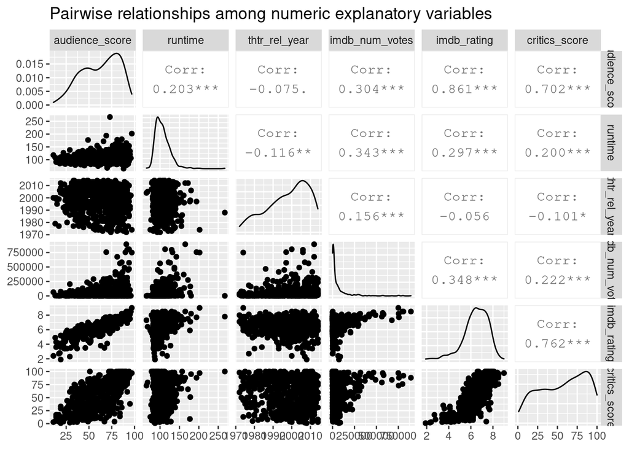

```r
ggpairs(dplyr::select(movies_new,audience_score,runtime, thtr_rel_year,imdb_num_votes,imdb_rating,critics_score),title = "Pairwise relationships among numeric explanatory variables")
```

We can see that critics_score and imdb_rating are highly correlated (0.762), as imdb_rating have a higher correlation (0.861) with audience_score when compared with critics_score (0.702), would be intereting keep it in the model and remove critics_score.

## Part 4: Modeling

let’s fit the model using the BIC:

```r
modelBIC <- bas.lm(audience_score ~
                     imdb_rating +  critics_score + runtime + imdb_num_votes +
                     feature_film + drama  + mpaa_rating_R + thtr_rel_year +
                     oscar_season + summer_season  +
                     best_pic_nom + best_pic_win + best_actor_win +
                     best_actress_win + best_dir_win + top200_box
                   , data = movies_new,
                   prior = "BIC",
                   modelprior = uniform())
summary(modelBIC)
```

```
##                     P(B != 0 | Y)    model 1       model 2       model 3
## Intercept              1.00000000     1.0000     1.0000000     1.0000000
## imdb_rating            1.00000000     1.0000     1.0000000     1.0000000
## critics_score          0.92015573     1.0000     1.0000000     1.0000000
## runtime                0.51399873     1.0000     0.0000000     0.0000000
## imdb_num_votes         0.06242230     0.0000     0.0000000     0.0000000
## feature_filmno         0.05876309     0.0000     0.0000000     0.0000000
## dramano                0.04508592     0.0000     0.0000000     0.0000000
## mpaa_rating_Rno        0.16498090     0.0000     0.0000000     0.0000000
## thtr_rel_year          0.08088668     0.0000     0.0000000     0.0000000
## oscar_seasonno         0.06525993     0.0000     0.0000000     0.0000000
## summer_seasonno        0.07935408     0.0000     0.0000000     0.0000000
## best_pic_nomyes        0.13200908     0.0000     0.0000000     0.0000000
## best_pic_winyes        0.04076727     0.0000     0.0000000     0.0000000
## best_actor_winyes      0.11565473     0.0000     0.0000000     0.0000000
## best_actress_winyes    0.14770126     0.0000     0.0000000     1.0000000
## best_dir_winyes        0.06701259     0.0000     0.0000000     0.0000000
## top200_boxyes          0.04875994     0.0000     0.0000000     0.0000000
## BF                             NA     1.0000     0.8715404     0.2048238
## PostProbs                      NA     0.1558     0.1358000     0.0319000
## R2                             NA     0.7483     0.7455000     0.7470000
## dim                            NA     4.0000     3.0000000     4.0000000
## logmarg                        NA -3434.7520 -3434.8894481 -3436.3375603
##                           model 4       model 5
## Intercept               1.0000000     1.0000000
## imdb_rating             1.0000000     1.0000000
## critics_score           1.0000000     1.0000000
## runtime                 1.0000000     1.0000000
## imdb_num_votes          0.0000000     0.0000000
## feature_filmno          0.0000000     0.0000000
## dramano                 0.0000000     0.0000000
## mpaa_rating_Rno         1.0000000     0.0000000
## thtr_rel_year           0.0000000     0.0000000
## oscar_seasonno          0.0000000     0.0000000
## summer_seasonno         0.0000000     0.0000000
## best_pic_nomyes         0.0000000     1.0000000
## best_pic_winyes         0.0000000     0.0000000
## best_actor_winyes       0.0000000     0.0000000
## best_actress_winyes     0.0000000     0.0000000
## best_dir_winyes         0.0000000     0.0000000
## top200_boxyes           0.0000000     0.0000000
## BF                      0.2039916     0.1851908
## PostProbs               0.0318000     0.0289000
## R2                      0.7496000     0.7495000
## dim                     5.0000000     5.0000000
## logmarg             -3436.3416317 -3436.4383237
```

We observe that imdb_rating, critics_score and runtime have posterior probabilities greater than 0.5 with mdb_rating, critics_score appering in all of the best models.

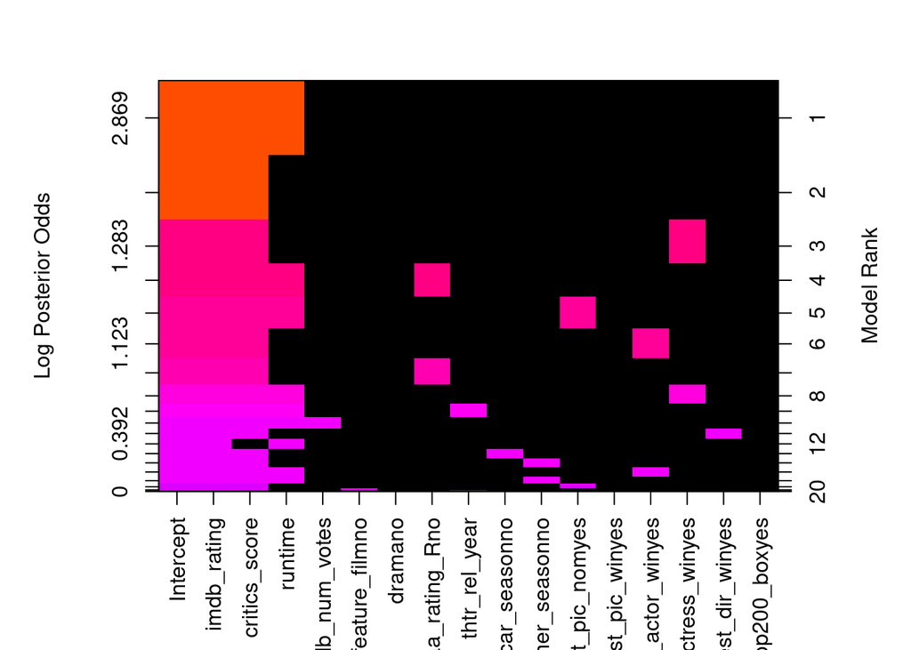

```r
image(modelBIC)
```

Analysing the linearity of this variables, we can see that all out them are clearly linear with audience_score except for runtime that have a difficult distribuiton to interpret

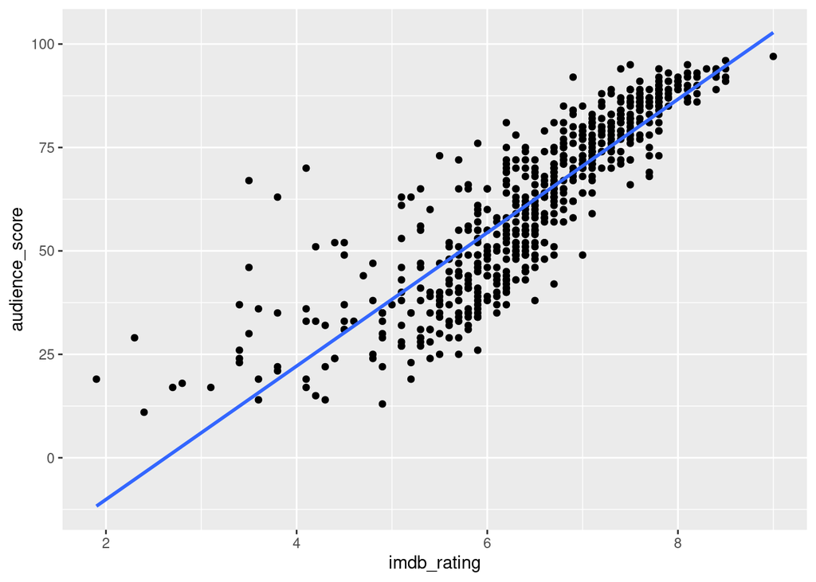

```r
p1 <- ggplot(data = movies, aes(x = imdb_rating, y = audience_score)) +
  geom_point() +
  stat_smooth(method = "lm", se = FALSE)
p1
```

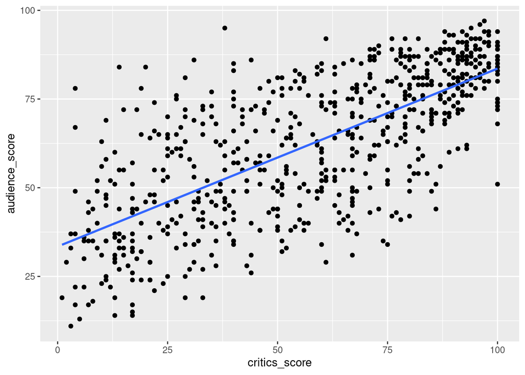

```r
p2 <- ggplot(data = movies, aes(x = critics_score, y = audience_score)) +
  geom_point() +
  stat_smooth(method = "lm", se = FALSE)
p2
```

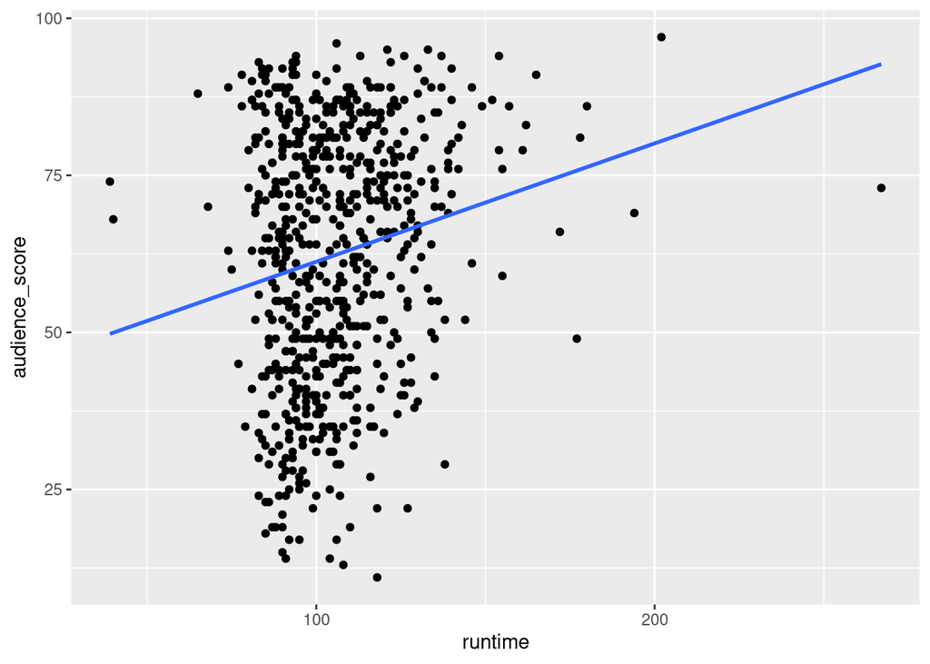

```r
p3 <- ggplot(data = movies, aes(x = runtime, y = audience_score)) +
  geom_point() +
  stat_smooth(method = "lm", se = FALSE)
p3
```

```r
coef <- coefficients(modelBIC)
confint(coef)
```

```
##                             2.5%        97.5%          beta
## Intercept           61.374559241 6.299457e+01  6.221002e+01
## imdb_rating         13.564352100 1.656970e+01  1.490680e+01
## critics_score        0.000000000 1.117895e-01  6.951964e-02
## runtime             -0.089604882 0.000000e+00 -3.042190e-02
## imdb_num_votes       0.000000000 2.837513e-06  2.466254e-07
## feature_filmno      -0.005842664 7.600304e-01  9.162435e-02
## dramano              0.000000000 0.000000e+00 -1.956484e-02
## mpaa_rating_Rno     -0.004634403 1.981565e+00  2.409288e-01
## thtr_rel_year       -0.045666287 6.327015e-04 -3.878883e-03
## oscar_seasonno       0.000000000 7.418764e-01  6.293171e-02
## summer_seasonno     -1.035127605 3.150709e-02 -8.660919e-02
## best_pic_nomyes      0.000000000 5.243922e+00  5.130600e-01
## best_pic_winyes      0.000000000 0.000000e+00 -6.383140e-03
## best_actor_winyes   -2.116403815 0.000000e+00 -2.123363e-01
## best_actress_winyes -3.060055398 0.000000e+00 -3.323225e-01
## best_dir_winyes     -1.437762945 3.375817e-03 -1.188402e-01
## top200_boxyes        0.000000000 0.000000e+00  8.972019e-02
## attr(,"Probability")
## [1] 0.95
## attr(,"class")
## [1] "confint.bas"
```

## Part 5: Prediction

To make prediciton, we would use tha same dataset to test if the model was fit correctly

```r
BMA <- predict(modelBIC, movies_new, estimator = "BMA", se.fit = TRUE)
ci_bma <- confint(BMA, estimator = "BMA")
opt_bma <- which.max(BMA$fit)
ci_bma[opt_bma, ]
```

```
##      2.5%     97.5%      pred
##  79.28740 121.31866  99.49639
```

## Part 6: Conclusion

We conclude that from all of that variables in the entire dataset, with BIC method, we can create a grat model with just 3 significant variables. ITo confirm the accuracy of this model it’s necessary to test with a new dataset and evaluate if it’s works better to new data when compared to other models.